# Risk Factor Analysis

## Outcome Variable

**Outcome Variable:** ever_wasted

## Predictor Variables

**Intervention Variable:** mage

**Adjustment Set:**

- arm
- meducyrs
- feducyrs
- W_mhtcm
- W_mwtkg
- W_mbmi
- single
- delta_meducyrs
- delta_feducyrs
- delta_W_mhtcm
- delta_W_mwtkg
- delta_W_mbmi
- delta_single

## Stratifying Variables

The analysis was stratified on these variable(s):

- agecat
- studyid
- country

## Data Summary

| agecat | studyid | country | mage | ever_wasted | n_cell | n |
| --- | --- | --- | --- | --- | --- | --- |
| 0-24 months | CMC-V-BCS-2002 | INDIA | [20-30) | 0 | 118 | 373 |
| 0-24 months | CMC-V-BCS-2002 | INDIA | [20-30) | 1 | 178 | 373 |
| 0-24 months | CMC-V-BCS-2002 | INDIA | <20 | 0 | 9 | 373 |
| 0-24 months | CMC-V-BCS-2002 | INDIA | <20 | 1 | 25 | 373 |
| 0-24 months | CMC-V-BCS-2002 | INDIA | >=30 | 0 | 18 | 373 |
| 0-24 months | CMC-V-BCS-2002 | INDIA | >=30 | 1 | 25 | 373 |
| 0-24 months | COHORTS | GUATEMALA | [20-30) | 0 | 492 | 1341 |
| 0-24 months | COHORTS | GUATEMALA | [20-30) | 1 | 163 | 1341 |
| 0-24 months | COHORTS | GUATEMALA | <20 | 0 | 146 | 1341 |
| 0-24 months | COHORTS | GUATEMALA | <20 | 1 | 50 | 1341 |
| 0-24 months | COHORTS | GUATEMALA | >=30 | 0 | 361 | 1341 |
| 0-24 months | COHORTS | GUATEMALA | >=30 | 1 | 129 | 1341 |
| 0-24 months | COHORTS | INDIA | [20-30) | 0 | 2449 | 5305 |
| 0-24 months | COHORTS | INDIA | [20-30) | 1 | 1148 | 5305 |
| 0-24 months | COHORTS | INDIA | <20 | 0 | 274 | 5305 |
| 0-24 months | COHORTS | INDIA | <20 | 1 | 152 | 5305 |
| 0-24 months | COHORTS | INDIA | >=30 | 0 | 800 | 5305 |
| 0-24 months | COHORTS | INDIA | >=30 | 1 | 482 | 5305 |
| 0-24 months | COHORTS | PHILIPPINES | [20-30) | 0 | 1106 | 3045 |
| 0-24 months | COHORTS | PHILIPPINES | [20-30) | 1 | 714 | 3045 |
| 0-24 months | COHORTS | PHILIPPINES | <20 | 0 | 208 | 3045 |
| 0-24 months | COHORTS | PHILIPPINES | <20 | 1 | 169 | 3045 |
| 0-24 months | COHORTS | PHILIPPINES | >=30 | 0 | 502 | 3045 |
| 0-24 months | COHORTS | PHILIPPINES | >=30 | 1 | 346 | 3045 |
| 0-24 months | EE | PAKISTAN | [20-30) | 0 | 73 | 377 |
| 0-24 months | EE | PAKISTAN | [20-30) | 1 | 89 | 377 |
| 0-24 months | EE | PAKISTAN | <20 | 0 | 0 | 377 |
| 0-24 months | EE | PAKISTAN | <20 | 1 | 1 | 377 |
| 0-24 months | EE | PAKISTAN | >=30 | 0 | 81 | 377 |
| 0-24 months | EE | PAKISTAN | >=30 | 1 | 133 | 377 |

[output cut: 450 more lines]

The following strata were considered:

- agecat: 0-24 months, studyid: CMC-V-BCS-2002, country: INDIA
- agecat: 0-24 months, studyid: COHORTS, country: GUATEMALA
- agecat: 0-24 months, studyid: COHORTS, country: INDIA
- agecat: 0-24 months, studyid: COHORTS, country: PHILIPPINES
- agecat: 0-24 months, studyid: EE, country: PAKISTAN
- agecat: 0-24 months, studyid: GMS-Nepal, country: NEPAL
- agecat: 0-24 months, studyid: Guatemala BSC, country: GUATEMALA
- agecat: 0-24 months, studyid: iLiNS-Zinc, country: BURKINA FASO
- agecat: 0-24 months, studyid: IRC, country: INDIA
- agecat: 0-24 months, studyid: JiVitA-3, country: BANGLADESH
- agecat: 0-24 months, studyid: Keneba, country: GAMBIA
- agecat: 0-24 months, studyid: LCNI-5, country: MALAWI
- agecat: 0-24 months, studyid: MAL-ED, country: BANGLADESH
- agecat: 0-24 months, studyid: MAL-ED, country: BRAZIL
- agecat: 0-24 months, studyid: MAL-ED, country: INDIA
- agecat: 0-24 months, studyid: MAL-ED, country: NEPAL
- agecat: 0-24 months, studyid: MAL-ED, country: PERU
- agecat: 0-24 months, studyid: MAL-ED, country: SOUTH AFRICA
- agecat: 0-24 months, studyid: MAL-ED, country: TANZANIA, UNITED REPUBLIC OF
- agecat: 0-24 months, studyid: NIH-Birth, country: BANGLADESH
- agecat: 0-24 months, studyid: NIH-Crypto, country: BANGLADESH
- agecat: 0-24 months, studyid: PROBIT, country: BELARUS
- agecat: 0-24 months, studyid: PROVIDE, country: BANGLADESH
- agecat: 0-24 months, studyid: SAS-CompFeed, country: INDIA
- agecat: 0-24 months, studyid: SAS-FoodSuppl, country: INDIA
- agecat: 0-24 months, studyid: TanzaniaChild2, country: TANZANIA, UNITED REPUBLIC OF
- agecat: 0-24 months, studyid: ZVITAMBO, country: ZIMBABWE
- agecat: 0-6 months, studyid: CMC-V-BCS-2002, country: INDIA
- agecat: 0-6 months, studyid: COHORTS, country: GUATEMALA
- agecat: 0-6 months, studyid: COHORTS, country: INDIA
- agecat: 0-6 months, studyid: COHORTS, country: PHILIPPINES
- agecat: 0-6 months, studyid: EE, country: PAKISTAN
- agecat: 0-6 months, studyid: GMS-Nepal, country: NEPAL
- agecat: 0-6 months, studyid: Guatemala BSC, country: GUATEMALA
- agecat: 0-6 months, studyid: IRC, country: INDIA
- agecat: 0-6 months, studyid: JiVitA-3, country: BANGLADESH
- agecat: 0-6 months, studyid: Keneba, country: GAMBIA
- agecat: 0-6 months, studyid: LCNI-5, country: MALAWI
- agecat: 0-6 months, studyid: MAL-ED, country: BANGLADESH
- agecat: 0-6 months, studyid: MAL-ED, country: BRAZIL
- agecat: 0-6 months, studyid: MAL-ED, country: INDIA
- agecat: 0-6 months, studyid: MAL-ED, country: NEPAL
- agecat: 0-6 months, studyid: MAL-ED, country: PERU
- agecat: 0-6 months, studyid: MAL-ED, country: SOUTH AFRICA
- agecat: 0-6 months, studyid: MAL-ED, country: TANZANIA, UNITED REPUBLIC OF
- agecat: 0-6 months, studyid: NIH-Birth, country: BANGLADESH
- agecat: 0-6 months, studyid: NIH-Crypto, country: BANGLADESH
- agecat: 0-6 months, studyid: PROBIT, country: BELARUS
- agecat: 0-6 months, studyid: PROVIDE, country: BANGLADESH
- agecat: 0-6 months, studyid: SAS-CompFeed, country: INDIA
- agecat: 0-6 months, studyid: SAS-FoodSuppl, country: INDIA
- agecat: 0-6 months, studyid: TanzaniaChild2, country: TANZANIA, UNITED REPUBLIC OF
- agecat: 0-6 months, studyid: ZVITAMBO, country: ZIMBABWE
- agecat: 6-24 months, studyid: CMC-V-BCS-2002, country: INDIA
- agecat: 6-24 months, studyid: COHORTS, country: GUATEMALA
- agecat: 6-24 months, studyid: COHORTS, country: INDIA
- agecat: 6-24 months, studyid: COHORTS, country: PHILIPPINES
- agecat: 6-24 months, studyid: EE, country: PAKISTAN
- agecat: 6-24 months, studyid: GMS-Nepal, country: NEPAL
- agecat: 6-24 months, studyid: Guatemala BSC, country: GUATEMALA
- agecat: 6-24 months, studyid: iLiNS-Zinc, country: BURKINA FASO
- agecat: 6-24 months, studyid: IRC, country: INDIA
- agecat: 6-24 months, studyid: JiVitA-3, country: BANGLADESH
- agecat: 6-24 months, studyid: Keneba, country: GAMBIA
- agecat: 6-24 months, studyid: LCNI-5, country: MALAWI
- agecat: 6-24 months, studyid: MAL-ED, country: BANGLADESH
- agecat: 6-24 months, studyid: MAL-ED, country: BRAZIL
- agecat: 6-24 months, studyid: MAL-ED, country: INDIA
- agecat: 6-24 months, studyid: MAL-ED, country: NEPAL
- agecat: 6-24 months, studyid: MAL-ED, country: PERU
- agecat: 6-24 months, studyid: MAL-ED, country: SOUTH AFRICA
- agecat: 6-24 months, studyid: MAL-ED, country: TANZANIA, UNITED REPUBLIC OF
- agecat: 6-24 months, studyid: NIH-Birth, country: BANGLADESH
- agecat: 6-24 months, studyid: NIH-Crypto, country: BANGLADESH
- agecat: 6-24 months, studyid: PROBIT, country: BELARUS
- agecat: 6-24 months, studyid: PROVIDE, country: BANGLADESH
- agecat: 6-24 months, studyid: SAS-CompFeed, country: INDIA
- agecat: 6-24 months, studyid: SAS-FoodSuppl, country: INDIA
- agecat: 6-24 months, studyid: TanzaniaChild2, country: TANZANIA, UNITED REPUBLIC OF
- agecat: 6-24 months, studyid: ZVITAMBO, country: ZIMBABWE

### Dropped Strata

Some strata were dropped due to rare outcomes:

- agecat: 0-24 months, studyid: EE, country: PAKISTAN
- agecat: 0-24 months, studyid: MAL-ED, country: BRAZIL
- agecat: 0-24 months, studyid: MAL-ED, country: NEPAL
- agecat: 0-24 months, studyid: MAL-ED, country: TANZANIA, UNITED REPUBLIC OF
- agecat: 0-6 months, studyid: EE, country: PAKISTAN
- agecat: 0-6 months, studyid: Guatemala BSC, country: GUATEMALA
- agecat: 0-6 months, studyid: LCNI-5, country: MALAWI
- agecat: 0-6 months, studyid: MAL-ED, country: BRAZIL
- agecat: 0-6 months, studyid: MAL-ED, country: INDIA
- agecat: 0-6 months, studyid: MAL-ED, country: NEPAL
- agecat: 0-6 months, studyid: MAL-ED, country: PERU
- agecat: 0-6 months, studyid: MAL-ED, country: TANZANIA, UNITED REPUBLIC OF
- agecat: 6-24 months, studyid: EE, country: PAKISTAN
- agecat: 6-24 months, studyid: Guatemala BSC, country: GUATEMALA
- agecat: 6-24 months, studyid: MAL-ED, country: BRAZIL
- agecat: 6-24 months, studyid: MAL-ED, country: INDIA
- agecat: 6-24 months, studyid: MAL-ED, country: NEPAL
- agecat: 6-24 months, studyid: MAL-ED, country: PERU
- agecat: 6-24 months, studyid: MAL-ED, country: TANZANIA, UNITED REPUBLIC OF

## Methods Detail

We’re interested in the causal parameters $E[Y_a]$ for all values of $a \in \mathcal{A}$. These parameters represent the mean outcome if, possibly contrary to fact, we intervened to set all units to have $A=a$. Under the randomization and positivity assumptions, these are identified by the statistical parameters $\psi_a=E_W[E_{Y|A,W}(Y|A=a,W)]$. In addition, we’re interested in the mean of $Y$, $E[Y]$ under no intervention (the observed mean). We will estimate these parameters by using SuperLearner to fit the relevant likelihood factors – $E_{Y|A,W}(Y|A=a,W)$ and $p(A=a|W)$, and then updating our likelihood fit using a joint TMLE.

For unadjusted analyses ($W=\{\}$), initial likelihoods were estimated using Lrnr_glm to estimate the simple $E(Y|A)$ and Lrnr_mean to estimate $p(A)$. For adjusted analyses, a small library containing Lrnr_glmnet, Lrnr_xgboost, and Lrnr_mean was used.

Having estimated these parameters, we will then use the delta method to estimate relative risks and attributable risks relative to a prespecified baseline level of $A$.

# Results Detail

## Results Plots

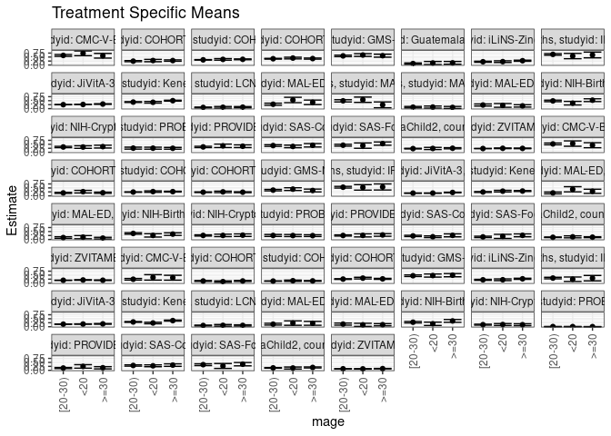

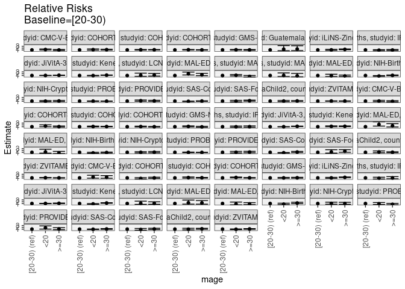

[figure not shown]

[figure not shown]

## Results Table

### Parameter: TSM

| agecat | studyid | country | intervention_level | baseline_level | estimate | ci_lower | ci_upper |
| --- | --- | --- | --- | --- | --- | --- | --- |
| 0-24 months | CMC-V-BCS-2002 | INDIA | [20-30) | NA | 0.6013514 | 0.5454986 | 0.6572041 |
| 0-24 months | CMC-V-BCS-2002 | INDIA | <20 | NA | 0.7352941 | 0.5868018 | 0.8837864 |
| 0-24 months | CMC-V-BCS-2002 | INDIA | >=30 | NA | 0.5813953 | 0.4337450 | 0.7290457 |
| 0-24 months | COHORTS | GUATEMALA | [20-30) | NA | 0.2430776 | 0.2092133 | 0.2769419 |
| 0-24 months | COHORTS | GUATEMALA | <20 | NA | 0.2810939 | 0.2076680 | 0.3545199 |
| 0-24 months | COHORTS | GUATEMALA | >=30 | NA | 0.2797723 | 0.2367367 | 0.3228079 |
| 0-24 months | COHORTS | INDIA | [20-30) | NA | 0.3248970 | 0.3093350 | 0.3404590 |
| 0-24 months | COHORTS | INDIA | <20 | NA | 0.3533293 | 0.3049299 | 0.4017286 |
| 0-24 months | COHORTS | INDIA | >=30 | NA | 0.3575777 | 0.3303603 | 0.3847952 |
| 0-24 months | COHORTS | PHILIPPINES | [20-30) | NA | 0.3940089 | 0.3712928 | 0.4167251 |
| 0-24 months | COHORTS | PHILIPPINES | <20 | NA | 0.4365473 | 0.3838494 | 0.4892452 |
| 0-24 months | COHORTS | PHILIPPINES | >=30 | NA | 0.4039293 | 0.3705647 | 0.4372940 |
| 0-24 months | GMS-Nepal | NEPAL | [20-30) | NA | 0.5731127 | 0.5266594 | 0.6195659 |
| 0-24 months | GMS-Nepal | NEPAL | <20 | NA | 0.6264320 | 0.5422885 | 0.7105754 |
| 0-24 months | GMS-Nepal | NEPAL | >=30 | NA | 0.5861047 | 0.4928743 | 0.6793351 |
| 0-24 months | Guatemala BSC | GUATEMALA | [20-30) | NA | 0.0914286 | 0.0486503 | 0.1342069 |
| 0-24 months | Guatemala BSC | GUATEMALA | <20 | NA | 0.1276596 | 0.0320849 | 0.2232343 |
| 0-24 months | Guatemala BSC | GUATEMALA | >=30 | NA | 0.1355932 | 0.0480799 | 0.2231066 |
| 0-24 months | iLiNS-Zinc | BURKINA FASO | [20-30) | NA | 0.2060971 | 0.1732686 | 0.2389256 |
| 0-24 months | iLiNS-Zinc | BURKINA FASO | <20 | NA | 0.2127695 | 0.1579991 | 0.2675399 |
| 0-24 months | iLiNS-Zinc | BURKINA FASO | >=30 | NA | 0.2701815 | 0.2347447 | 0.3056182 |
| 0-24 months | IRC | INDIA | [20-30) | NA | 0.6682580 | 0.6183604 | 0.7181555 |
| 0-24 months | IRC | INDIA | <20 | NA | 0.5636423 | 0.3956920 | 0.7315927 |
| 0-24 months | IRC | INDIA | >=30 | NA | 0.6313691 | 0.4508013 | 0.8119368 |
| 0-24 months | JiVitA-3 | BANGLADESH | [20-30) | NA | 0.2499380 | 0.2407578 | 0.2591181 |
| 0-24 months | JiVitA-3 | BANGLADESH | <20 | NA | 0.2626187 | 0.2529664 | 0.2722710 |
| 0-24 months | JiVitA-3 | BANGLADESH | >=30 | NA | 0.2885610 | 0.2672696 | 0.3098525 |
| 0-24 months | Keneba | GAMBIA | [20-30) | NA | 0.4116054 | 0.3855432 | 0.4376676 |
| 0-24 months | Keneba | GAMBIA | <20 | NA | 0.3996519 | 0.3485976 | 0.4507062 |
| 0-24 months | Keneba | GAMBIA | >=30 | NA | 0.4990328 | 0.4681071 | 0.5299585 |

[output cut: 153 more lines]

### Parameter: E(Y)

| agecat | studyid | country | intervention_level | baseline_level | estimate | ci_lower | ci_upper |
| --- | --- | --- | --- | --- | --- | --- | --- |
| 0-24 months | CMC-V-BCS-2002 | INDIA | NA | NA | 0.6112601 | 0.5617242 | 0.6607959 |
| 0-24 months | COHORTS | GUATEMALA | NA | NA | 0.2550336 | 0.2316956 | 0.2783715 |
| 0-24 months | COHORTS | INDIA | NA | NA | 0.3359095 | 0.3231988 | 0.3486203 |
| 0-24 months | COHORTS | PHILIPPINES | NA | NA | 0.4036125 | 0.3861835 | 0.4210415 |
| 0-24 months | GMS-Nepal | NEPAL | NA | NA | 0.5903790 | 0.5535526 | 0.6272054 |
| 0-24 months | Guatemala BSC | GUATEMALA | NA | NA | 0.1067616 | 0.0705906 | 0.1429325 |
| 0-24 months | iLiNS-Zinc | BURKINA FASO | NA | NA | 0.2274300 | 0.2005343 | 0.2543257 |
| 0-24 months | IRC | INDIA | NA | NA | 0.6560976 | 0.6100625 | 0.7021326 |
| 0-24 months | JiVitA-3 | BANGLADESH | NA | NA | 0.2580813 | 0.2516131 | 0.2645495 |
| 0-24 months | Keneba | GAMBIA | NA | NA | 0.4437849 | 0.4255860 | 0.4619838 |
| 0-24 months | LCNI-5 | MALAWI | NA | NA | 0.0805970 | 0.0599695 | 0.1012246 |
| 0-24 months | MAL-ED | BANGLADESH | NA | NA | 0.3307985 | 0.2738270 | 0.3877700 |
| 0-24 months | MAL-ED | INDIA | NA | NA | 0.4779116 | 0.4157435 | 0.5400798 |
| 0-24 months | MAL-ED | PERU | NA | NA | 0.0894040 | 0.0571706 | 0.1216374 |
| 0-24 months | MAL-ED | SOUTH AFRICA | NA | NA | 0.2051282 | 0.1602507 | 0.2500058 |
| 0-24 months | NIH-Birth | BANGLADESH | NA | NA | 0.4774920 | 0.4382065 | 0.5167774 |
| 0-24 months | NIH-Crypto | BANGLADESH | NA | NA | 0.3298153 | 0.2963239 | 0.3633067 |
| 0-24 months | PROBIT | BELARUS | NA | NA | 0.2554148 | 0.1971257 | 0.3137040 |
| 0-24 months | PROVIDE | BANGLADESH | NA | NA | 0.3514286 | 0.3160364 | 0.3868207 |
| 0-24 months | SAS-CompFeed | INDIA | NA | NA | 0.4150694 | 0.3581204 | 0.4720184 |
| 0-24 months | SAS-FoodSuppl | INDIA | NA | NA | 0.4712919 | 0.4233811 | 0.5192026 |
| 0-24 months | TanzaniaChild2 | TANZANIA, UNITED REPUBLIC OF | NA | NA | 0.2369529 | 0.2198518 | 0.2540539 |
| 0-24 months | ZVITAMBO | ZIMBABWE | NA | NA | 0.2365545 | 0.2294916 | 0.2436174 |
| 0-6 months | CMC-V-BCS-2002 | INDIA | NA | NA | 0.5163043 | 0.4651769 | 0.5674318 |
| 0-6 months | COHORTS | GUATEMALA | NA | NA | 0.2003763 | 0.1763021 | 0.2244505 |
| 0-6 months | COHORTS | INDIA | NA | NA | 0.2500980 | 0.2382136 | 0.2619824 |
| 0-6 months | COHORTS | PHILIPPINES | NA | NA | 0.2355453 | 0.2204685 | 0.2506222 |
| 0-6 months | GMS-Nepal | NEPAL | NA | NA | 0.3760933 | 0.3398180 | 0.4123685 |
| 0-6 months | IRC | INDIA | NA | NA | 0.5439024 | 0.4956326 | 0.5921723 |
| 0-6 months | JiVitA-3 | BANGLADESH | NA | NA | 0.1762142 | 0.1705882 | 0.1818403 |
| 0-6 months | Keneba | GAMBIA | NA | NA | 0.2749591 | 0.2572539 | 0.2926643 |
| 0-6 months | MAL-ED | BANGLADESH | NA | NA | 0.2281369 | 0.1773250 | 0.2789488 |
| 0-6 months | MAL-ED | SOUTH AFRICA | NA | NA | 0.1121795 | 0.0771053 | 0.1472536 |
| 0-6 months | NIH-Birth | BANGLADESH | NA | NA | 0.3580645 | 0.3202961 | 0.3958330 |
| 0-6 months | NIH-Crypto | BANGLADESH | NA | NA | 0.2572559 | 0.2261171 | 0.2883948 |
| 0-6 months | PROBIT | BELARUS | NA | NA | 0.2500148 | 0.1915461 | 0.3084835 |
| 0-6 months | PROVIDE | BANGLADESH | NA | NA | 0.2585714 | 0.2261125 | 0.2910304 |
| 0-6 months | SAS-CompFeed | INDIA | NA | NA | 0.2199336 | 0.1753445 | 0.2645227 |
| 0-6 months | SAS-FoodSuppl | INDIA | NA | NA | 0.1866029 | 0.1492099 | 0.2239959 |
| 0-6 months | TanzaniaChild2 | TANZANIA, UNITED REPUBLIC OF | NA | NA | 0.1397306 | 0.1257869 | 0.1536744 |
| 0-6 months | ZVITAMBO | ZIMBABWE | NA | NA | 0.1808903 | 0.1744713 | 0.1873093 |
| 6-24 months | CMC-V-BCS-2002 | INDIA | NA | NA | 0.2654155 | 0.2205451 | 0.3102860 |
| 6-24 months | COHORTS | GUATEMALA | NA | NA | 0.1269580 | 0.1082147 | 0.1457012 |
| 6-24 months | COHORTS | INDIA | NA | NA | 0.1317329 | 0.1223171 | 0.1411487 |
| 6-24 months | COHORTS | PHILIPPINES | NA | NA | 0.2666429 | 0.2502871 | 0.2829988 |
| 6-24 months | GMS-Nepal | NEPAL | NA | NA | 0.4728814 | 0.4325613 | 0.5132014 |
| 6-24 months | iLiNS-Zinc | BURKINA FASO | NA | NA | 0.2274300 | 0.2005343 | 0.2543257 |
| 6-24 months | IRC | INDIA | NA | NA | 0.3097561 | 0.2649438 | 0.3545684 |
| 6-24 months | JiVitA-3 | BANGLADESH | NA | NA | 0.1640643 | 0.1579507 | 0.1701779 |
| 6-24 months | Keneba | GAMBIA | NA | NA | 0.3201934 | 0.3025561 | 0.3378307 |
| 6-24 months | LCNI-5 | MALAWI | NA | NA | 0.0789074 | 0.0583085 | 0.0995064 |
| 6-24 months | MAL-ED | BANGLADESH | NA | NA | 0.1791667 | 0.1305478 | 0.2277856 |
| 6-24 months | MAL-ED | SOUTH AFRICA | NA | NA | 0.1428571 | 0.1001583 | 0.1855560 |
| 6-24 months | NIH-Birth | BANGLADESH | NA | NA | 0.2925926 | 0.2541847 | 0.3310005 |
| 6-24 months | NIH-Crypto | BANGLADESH | NA | NA | 0.1315068 | 0.1069744 | 0.1560393 |
| 6-24 months | PROBIT | BELARUS | NA | NA | 0.0083745 | 0.0044130 | 0.0123360 |
| 6-24 months | PROVIDE | BANGLADESH | NA | NA | 0.1609756 | 0.1319065 | 0.1900447 |
| 6-24 months | SAS-CompFeed | INDIA | NA | NA | 0.3059755 | 0.2638053 | 0.3481458 |
| 6-24 months | SAS-FoodSuppl | INDIA | NA | NA | 0.3557214 | 0.3088651 | 0.4025777 |
| 6-24 months | TanzaniaChild2 | TANZANIA, UNITED REPUBLIC OF | NA | NA | 0.1607589 | 0.1446692 | 0.1768485 |
| 6-24 months | ZVITAMBO | ZIMBABWE | NA | NA | 0.0959310 | 0.0903738 | 0.1014883 |

### Parameter: RR

| agecat | studyid | country | intervention_level | baseline_level | estimate | ci_lower | ci_upper |
| --- | --- | --- | --- | --- | --- | --- | --- |
| 0-24 months | CMC-V-BCS-2002 | INDIA | [20-30) | [20-30) | 1.0000000 | 1.0000000 | 1.0000000 |
| 0-24 months | CMC-V-BCS-2002 | INDIA | <20 | [20-30) | 1.2227363 | 0.9790304 | 1.5271068 |
| 0-24 months | CMC-V-BCS-2002 | INDIA | >=30 | [20-30) | 0.9668147 | 0.7377441 | 1.2670121 |
| 0-24 months | COHORTS | GUATEMALA | [20-30) | [20-30) | 1.0000000 | 1.0000000 | 1.0000000 |
| 0-24 months | COHORTS | GUATEMALA | <20 | [20-30) | 1.1563960 | 0.8613065 | 1.5525852 |
| 0-24 months | COHORTS | GUATEMALA | >=30 | [20-30) | 1.1509589 | 0.9364413 | 1.4146178 |
| 0-24 months | COHORTS | INDIA | [20-30) | [20-30) | 1.0000000 | 1.0000000 | 1.0000000 |
| 0-24 months | COHORTS | INDIA | <20 | [20-30) | 1.0875116 | 0.9406535 | 1.2572978 |
| 0-24 months | COHORTS | INDIA | >=30 | [20-30) | 1.1005880 | 1.0060674 | 1.2039888 |
| 0-24 months | COHORTS | PHILIPPINES | [20-30) | [20-30) | 1.0000000 | 1.0000000 | 1.0000000 |
| 0-24 months | COHORTS | PHILIPPINES | <20 | [20-30) | 1.1079629 | 0.9692698 | 1.2665018 |
| 0-24 months | COHORTS | PHILIPPINES | >=30 | [20-30) | 1.0251781 | 0.9269737 | 1.1337863 |
| 0-24 months | GMS-Nepal | NEPAL | [20-30) | [20-30) | 1.0000000 | 1.0000000 | 1.0000000 |
| 0-24 months | GMS-Nepal | NEPAL | <20 | [20-30) | 1.0930346 | 0.9342943 | 1.2787454 |
| 0-24 months | GMS-Nepal | NEPAL | >=30 | [20-30) | 1.0226693 | 0.8554698 | 1.2225475 |
| 0-24 months | Guatemala BSC | GUATEMALA | [20-30) | [20-30) | 1.0000000 | 1.0000000 | 1.0000000 |
| 0-24 months | Guatemala BSC | GUATEMALA | <20 | [20-30) | 1.3962766 | 0.5775036 | 3.3758896 |
| 0-24 months | Guatemala BSC | GUATEMALA | >=30 | [20-30) | 1.4830508 | 0.6682686 | 3.2912512 |
| 0-24 months | iLiNS-Zinc | BURKINA FASO | [20-30) | [20-30) | 1.0000000 | 1.0000000 | 1.0000000 |
| 0-24 months | iLiNS-Zinc | BURKINA FASO | <20 | [20-30) | 1.0323749 | 0.7962843 | 1.3384641 |
| 0-24 months | iLiNS-Zinc | BURKINA FASO | >=30 | [20-30) | 1.3109424 | 1.1105841 | 1.5474470 |
| 0-24 months | IRC | INDIA | [20-30) | [20-30) | 1.0000000 | 1.0000000 | 1.0000000 |
| 0-24 months | IRC | INDIA | <20 | [20-30) | 0.8434502 | 0.6202935 | 1.1468897 |
| 0-24 months | IRC | INDIA | >=30 | [20-30) | 0.9447984 | 0.7029520 | 1.2698506 |
| 0-24 months | JiVitA-3 | BANGLADESH | [20-30) | [20-30) | 1.0000000 | 1.0000000 | 1.0000000 |
| 0-24 months | JiVitA-3 | BANGLADESH | <20 | [20-30) | 1.0507354 | 1.0012924 | 1.1026198 |
| 0-24 months | JiVitA-3 | BANGLADESH | >=30 | [20-30) | 1.1545306 | 1.0661790 | 1.2502037 |
| 0-24 months | Keneba | GAMBIA | [20-30) | [20-30) | 1.0000000 | 1.0000000 | 1.0000000 |
| 0-24 months | Keneba | GAMBIA | <20 | [20-30) | 0.9709589 | 0.8418872 | 1.1198188 |
| 0-24 months | Keneba | GAMBIA | >=30 | [20-30) | 1.2124059 | 1.1099988 | 1.3242610 |

[output cut: 153 more lines]

### Parameter: PAR

| agecat | studyid | country | intervention_level | baseline_level | estimate | ci_lower | ci_upper |
| --- | --- | --- | --- | --- | --- | --- | --- |
| 0-24 months | CMC-V-BCS-2002 | INDIA | [20-30) | NA | 0.0099087 | -0.0150357 | 0.0348531 |
| 0-24 months | COHORTS | GUATEMALA | [20-30) | NA | 0.0119560 | -0.0130790 | 0.0369910 |
| 0-24 months | COHORTS | INDIA | [20-30) | NA | 0.0110125 | 0.0017864 | 0.0202387 |
| 0-24 months | COHORTS | PHILIPPINES | [20-30) | NA | 0.0096035 | -0.0050240 | 0.0242311 |
| 0-24 months | GMS-Nepal | NEPAL | [20-30) | NA | 0.0172663 | -0.0101130 | 0.0446456 |
| 0-24 months | Guatemala BSC | GUATEMALA | [20-30) | NA | 0.0153330 | -0.0139754 | 0.0446414 |
| 0-24 months | iLiNS-Zinc | BURKINA FASO | [20-30) | NA | 0.0213329 | 0.0061032 | 0.0365625 |
| 0-24 months | IRC | INDIA | [20-30) | NA | -0.0121604 | -0.0332069 | 0.0088861 |
| 0-24 months | JiVitA-3 | BANGLADESH | [20-30) | NA | 0.0081433 | 0.0018127 | 0.0144739 |
| 0-24 months | Keneba | GAMBIA | [20-30) | NA | 0.0321795 | 0.0134179 | 0.0509411 |
| 0-24 months | LCNI-5 | MALAWI | [20-30) | NA | 0.0064212 | -0.0126225 | 0.0254649 |
| 0-24 months | MAL-ED | BANGLADESH | [20-30) | NA | 0.0548986 | 0.0142655 | 0.0955317 |
| 0-24 months | MAL-ED | INDIA | [20-30) | NA | -0.0117791 | -0.0448166 | 0.0212585 |
| 0-24 months | MAL-ED | PERU | [20-30) | NA | -0.0020993 | -0.0338995 | 0.0297009 |
| 0-24 months | MAL-ED | SOUTH AFRICA | [20-30) | NA | -0.0216540 | -0.0658880 | 0.0225800 |
| 0-24 months | NIH-Birth | BANGLADESH | [20-30) | NA | -0.0076937 | -0.0353062 | 0.0199188 |
| 0-24 months | NIH-Crypto | BANGLADESH | [20-30) | NA | -0.0000877 | -0.0246500 | 0.0244745 |
| 0-24 months | PROBIT | BELARUS | [20-30) | NA | -0.0031199 | -0.0096092 | 0.0033694 |
| 0-24 months | PROVIDE | BANGLADESH | [20-30) | NA | 0.0167494 | -0.0065397 | 0.0400384 |
| 0-24 months | SAS-CompFeed | INDIA | [20-30) | NA | -0.0047415 | -0.0139695 | 0.0044866 |
| 0-24 months | SAS-FoodSuppl | INDIA | [20-30) | NA | 0.0298362 | -0.0025434 | 0.0622159 |
| 0-24 months | TanzaniaChild2 | TANZANIA, UNITED REPUBLIC OF | [20-30) | NA | 0.0072805 | -0.0051164 | 0.0196774 |
| 0-24 months | ZVITAMBO | ZIMBABWE | [20-30) | NA | 0.0025921 | -0.0029617 | 0.0081459 |
| 0-6 months | CMC-V-BCS-2002 | INDIA | [20-30) | NA | -0.0070800 | -0.0333347 | 0.0191747 |
| 0-6 months | COHORTS | GUATEMALA | [20-30) | NA | 0.0152359 | -0.0096639 | 0.0401358 |
| 0-6 months | COHORTS | INDIA | [20-30) | NA | 0.0106468 | 0.0020151 | 0.0192784 |
| 0-6 months | COHORTS | PHILIPPINES | [20-30) | NA | 0.0052958 | -0.0074565 | 0.0180482 |
| 0-6 months | GMS-Nepal | NEPAL | [20-30) | NA | 0.0149846 | -0.0121288 | 0.0420980 |
| 0-6 months | IRC | INDIA | [20-30) | NA | 0.0003753 | -0.0208666 | 0.0216172 |
| 0-6 months | JiVitA-3 | BANGLADESH | [20-30) | NA | 0.0039843 | -0.0015555 | 0.0095242 |
| 0-6 months | Keneba | GAMBIA | [20-30) | NA | 0.0321537 | 0.0133811 | 0.0509263 |
| 0-6 months | MAL-ED | BANGLADESH | [20-30) | NA | 0.0434584 | 0.0058893 | 0.0810275 |
| 0-6 months | MAL-ED | SOUTH AFRICA | [20-30) | NA | -0.0073174 | -0.0416853 | 0.0270505 |
| 0-6 months | NIH-Birth | BANGLADESH | [20-30) | NA | -0.0221285 | -0.0482002 | 0.0039431 |
| 0-6 months | NIH-Crypto | BANGLADESH | [20-30) | NA | 0.0023046 | -0.0206581 | 0.0252673 |
| 0-6 months | PROBIT | BELARUS | [20-30) | NA | -0.0032943 | -0.0097070 | 0.0031185 |
| 0-6 months | PROVIDE | BANGLADESH | [20-30) | NA | 0.0063676 | -0.0149629 | 0.0276982 |
| 0-6 months | SAS-CompFeed | INDIA | [20-30) | NA | -0.0044653 | -0.0143501 | 0.0054195 |
| 0-6 months | SAS-FoodSuppl | INDIA | [20-30) | NA | 0.0245339 | -0.0019120 | 0.0509798 |
| 0-6 months | TanzaniaChild2 | TANZANIA, UNITED REPUBLIC OF | [20-30) | NA | 0.0020718 | -0.0080538 | 0.0121975 |
| 0-6 months | ZVITAMBO | ZIMBABWE | [20-30) | NA | 0.0036658 | -0.0012004 | 0.0085321 |
| 6-24 months | CMC-V-BCS-2002 | INDIA | [20-30) | NA | 0.0226995 | -0.0018720 | 0.0472710 |
| 6-24 months | COHORTS | GUATEMALA | [20-30) | NA | -0.0052958 | -0.0246362 | 0.0140445 |
| 6-24 months | COHORTS | INDIA | [20-30) | NA | 0.0047721 | -0.0023960 | 0.0119402 |
| 6-24 months | COHORTS | PHILIPPINES | [20-30) | NA | 0.0136554 | -0.0002818 | 0.0275927 |
| 6-24 months | GMS-Nepal | NEPAL | [20-30) | NA | 0.0098989 | -0.0203164 | 0.0401142 |
| 6-24 months | iLiNS-Zinc | BURKINA FASO | [20-30) | NA | 0.0213182 | 0.0063531 | 0.0362833 |
| 6-24 months | IRC | INDIA | [20-30) | NA | -0.0071044 | -0.0262133 | 0.0120045 |
| 6-24 months | JiVitA-3 | BANGLADESH | [20-30) | NA | 0.0034172 | -0.0035139 | 0.0103482 |
| 6-24 months | Keneba | GAMBIA | [20-30) | NA | 0.0200773 | 0.0017106 | 0.0384441 |
| 6-24 months | LCNI-5 | MALAWI | [20-30) | NA | 0.0032772 | -0.0157344 | 0.0222887 |
| 6-24 months | MAL-ED | BANGLADESH | [20-30) | NA | 0.0196575 | -0.0153694 | 0.0546844 |
| 6-24 months | MAL-ED | SOUTH AFRICA | [20-30) | NA | -0.0210773 | -0.0666196 | 0.0244650 |
| 6-24 months | NIH-Birth | BANGLADESH | [20-30) | NA | 0.0093343 | -0.0181539 | 0.0368224 |
| 6-24 months | NIH-Crypto | BANGLADESH | [20-30) | NA | 0.0032411 | -0.0149837 | 0.0214659 |
| 6-24 months | PROBIT | BELARUS | [20-30) | NA | -0.0007567 | -0.0016995 | 0.0001860 |
| 6-24 months | PROVIDE | BANGLADESH | [20-30) | NA | 0.0157220 | -0.0040766 | 0.0355205 |
| 6-24 months | SAS-CompFeed | INDIA | [20-30) | NA | 0.0007817 | -0.0085048 | 0.0100682 |
| 6-24 months | SAS-FoodSuppl | INDIA | [20-30) | NA | -0.0000465 | -0.0312943 | 0.0312013 |
| 6-24 months | TanzaniaChild2 | TANZANIA, UNITED REPUBLIC OF | [20-30) | NA | 0.0062723 | -0.0055733 | 0.0181179 |
| 6-24 months | ZVITAMBO | ZIMBABWE | [20-30) | NA | -0.0014875 | -0.0061406 | 0.0031656 |

### Parameter: PAF

| agecat | studyid | country | intervention_level | baseline_level | estimate | ci_lower | ci_upper |
| --- | --- | --- | --- | --- | --- | --- | --- |
| 0-24 months | CMC-V-BCS-2002 | INDIA | [20-30) | NA | 0.0162103 | -0.0255022 | 0.0562261 |
| 0-24 months | COHORTS | GUATEMALA | [20-30) | NA | 0.0468801 | -0.0565203 | 0.1401607 |
| 0-24 months | COHORTS | INDIA | [20-30) | NA | 0.0327842 | 0.0049201 | 0.0598680 |
| 0-24 months | COHORTS | PHILIPPINES | [20-30) | NA | 0.0237940 | -0.0131403 | 0.0593818 |
| 0-24 months | GMS-Nepal | NEPAL | [20-30) | NA | 0.0292462 | -0.0183422 | 0.0746107 |
| 0-24 months | Guatemala BSC | GUATEMALA | [20-30) | NA | 0.1436190 | -0.1752619 | 0.3759788 |
| 0-24 months | iLiNS-Zinc | BURKINA FASO | [20-30) | NA | 0.0937998 | 0.0215734 | 0.1606945 |
| 0-24 months | IRC | INDIA | [20-30) | NA | -0.0185344 | -0.0512005 | 0.0131166 |
| 0-24 months | JiVitA-3 | BANGLADESH | [20-30) | NA | 0.0315532 | 0.0066739 | 0.0558094 |
| 0-24 months | Keneba | GAMBIA | [20-30) | NA | 0.0725116 | 0.0291656 | 0.1139222 |
| 0-24 months | LCNI-5 | MALAWI | [20-30) | NA | 0.0796703 | -0.1887603 | 0.2874874 |
| 0-24 months | MAL-ED | BANGLADESH | [20-30) | NA | 0.1659579 | 0.0341263 | 0.2797959 |
| 0-24 months | MAL-ED | INDIA | [20-30) | NA | -0.0246470 | -0.0962308 | 0.0422625 |
| 0-24 months | MAL-ED | PERU | [20-30) | NA | -0.0234810 | -0.4486935 | 0.2769255 |
| 0-24 months | MAL-ED | SOUTH AFRICA | [20-30) | NA | -0.1055634 | -0.3429793 | 0.0898814 |
| 0-24 months | NIH-Birth | BANGLADESH | [20-30) | NA | -0.0161127 | -0.0756408 | 0.0401210 |
| 0-24 months | NIH-Crypto | BANGLADESH | [20-30) | NA | -0.0002660 | -0.0775812 | 0.0715019 |
| 0-24 months | PROBIT | BELARUS | [20-30) | NA | -0.0122150 | -0.0367576 | 0.0117467 |
| 0-24 months | PROVIDE | BANGLADESH | [20-30) | NA | 0.0476608 | -0.0209349 | 0.1116475 |
| 0-24 months | SAS-CompFeed | INDIA | [20-30) | NA | -0.0114233 | -0.0346989 | 0.0113287 |
| 0-24 months | SAS-FoodSuppl | INDIA | [20-30) | NA | 0.0633074 | -0.0082041 | 0.1297466 |
| 0-24 months | TanzaniaChild2 | TANZANIA, UNITED REPUBLIC OF | [20-30) | NA | 0.0307255 | -0.0230322 | 0.0816584 |
| 0-24 months | ZVITAMBO | ZIMBABWE | [20-30) | NA | 0.0109575 | -0.0128027 | 0.0341603 |
| 0-6 months | CMC-V-BCS-2002 | INDIA | [20-30) | NA | -0.0137129 | -0.0658794 | 0.0359006 |
| 0-6 months | COHORTS | GUATEMALA | [20-30) | NA | 0.0760366 | -0.0568012 | 0.1921770 |
| 0-6 months | COHORTS | INDIA | [20-30) | NA | 0.0425703 | 0.0074459 | 0.0764518 |
| 0-6 months | COHORTS | PHILIPPINES | [20-30) | NA | 0.0224833 | -0.0331849 | 0.0751520 |
| 0-6 months | GMS-Nepal | NEPAL | [20-30) | NA | 0.0398428 | -0.0350720 | 0.1093355 |
| 0-6 months | IRC | INDIA | [20-30) | NA | 0.0006900 | -0.0391379 | 0.0389915 |
| 0-6 months | JiVitA-3 | BANGLADESH | [20-30) | NA | 0.0226108 | -0.0093607 | 0.0535697 |
| 0-6 months | Keneba | GAMBIA | [20-30) | NA | 0.1169399 | 0.0460192 | 0.1825883 |
| 0-6 months | MAL-ED | BANGLADESH | [20-30) | NA | 0.1904926 | 0.0116220 | 0.3369923 |
| 0-6 months | MAL-ED | SOUTH AFRICA | [20-30) | NA | -0.0652291 | -0.4195344 | 0.2006442 |
| 0-6 months | NIH-Birth | BANGLADESH | [20-30) | NA | -0.0618004 | -0.1372285 | 0.0086248 |
| 0-6 months | NIH-Crypto | BANGLADESH | [20-30) | NA | 0.0089583 | -0.0844455 | 0.0943171 |
| 0-6 months | PROBIT | BELARUS | [20-30) | NA | -0.0131763 | -0.0378458 | 0.0109069 |
| 0-6 months | PROVIDE | BANGLADESH | [20-30) | NA | 0.0246261 | -0.0614292 | 0.1037046 |
| 0-6 months | SAS-CompFeed | INDIA | [20-30) | NA | -0.0203030 | -0.0693779 | 0.0265199 |
| 0-6 months | SAS-FoodSuppl | INDIA | [20-30) | NA | 0.1314766 | -0.0207230 | 0.2609817 |
| 0-6 months | TanzaniaChild2 | TANZANIA, UNITED REPUBLIC OF | [20-30) | NA | 0.0148272 | -0.0603740 | 0.0846951 |
| 0-6 months | ZVITAMBO | ZIMBABWE | [20-30) | NA | 0.0202654 | -0.0070090 | 0.0468010 |
| 6-24 months | CMC-V-BCS-2002 | INDIA | [20-30) | NA | 0.0855242 | -0.0115841 | 0.1733105 |
| 6-24 months | COHORTS | GUATEMALA | [20-30) | NA | -0.0417131 | -0.2055703 | 0.0998732 |
| 6-24 months | COHORTS | INDIA | [20-30) | NA | 0.0362254 | -0.0196902 | 0.0890749 |
| 6-24 months | COHORTS | PHILIPPINES | [20-30) | NA | 0.0512124 | -0.0025080 | 0.1020541 |
| 6-24 months | GMS-Nepal | NEPAL | [20-30) | NA | 0.0209332 | -0.0451423 | 0.0828313 |
| 6-24 months | iLiNS-Zinc | BURKINA FASO | [20-30) | NA | 0.0937350 | 0.0230993 | 0.1592634 |
| 6-24 months | IRC | INDIA | [20-30) | NA | -0.0229354 | -0.0865158 | 0.0369245 |
| 6-24 months | JiVitA-3 | BANGLADESH | [20-30) | NA | 0.0208282 | -0.0223145 | 0.0621502 |
| 6-24 months | Keneba | GAMBIA | [20-30) | NA | 0.0627037 | 0.0035190 | 0.1183732 |
| 6-24 months | LCNI-5 | MALAWI | [20-30) | NA | 0.0415320 | -0.2321283 | 0.2544113 |
| 6-24 months | MAL-ED | BANGLADESH | [20-30) | NA | 0.1097161 | -0.1071782 | 0.2841211 |
| 6-24 months | MAL-ED | SOUTH AFRICA | [20-30) | NA | -0.1475410 | -0.5125291 | 0.1293719 |
| 6-24 months | NIH-Birth | BANGLADESH | [20-30) | NA | 0.0319020 | -0.0667609 | 0.1214397 |
| 6-24 months | NIH-Crypto | BANGLADESH | [20-30) | NA | 0.0246458 | -0.1242348 | 0.1538105 |
| 6-24 months | PROBIT | BELARUS | [20-30) | NA | -0.0903616 | -0.1915635 | 0.0022450 |
| 6-24 months | PROVIDE | BANGLADESH | [20-30) | NA | 0.0976668 | -0.0330863 | 0.2118710 |
| 6-24 months | SAS-CompFeed | INDIA | [20-30) | NA | 0.0025546 | -0.0281691 | 0.0323602 |
| 6-24 months | SAS-FoodSuppl | INDIA | [20-30) | NA | -0.0001307 | -0.0919474 | 0.0839655 |
| 6-24 months | TanzaniaChild2 | TANZANIA, UNITED REPUBLIC OF | [20-30) | NA | 0.0390166 | -0.0375523 | 0.1099349 |
| 6-24 months | ZVITAMBO | ZIMBABWE | [20-30) | NA | -0.0155060 | -0.0651725 | 0.0318447 |